# Predictors of National Carbon Dioxide Emissions

by Nat Goodby & James Valadez

*Central Question:* Are urbanization rates and GDP per capita predictors of a country’s carbon dioxide emmissions?

This question intrigued us because urbanization and GDP per capita generally increase as a country’s level of development increases. Should we then expect CO2 emissions to rise as urbanization and GDP per capita rise? As GDP per capita rises, levels of consumption can be expected to rise simultaneously, which often leads to larger carbon footprints for a country’s citizens. At the same time, increased development can also lead to more technological development and access. Some countries have been able to take advantage of technologies to slow emissions by harnessing more renewable energies. Increased urbanization could theoretically also cause CO2 emissions to move in either direction. Increased urbanization may reduce transportation needs for people living in cities and work to reduce CO2 emissions overall. Increasing industrialization and growth of cities, however, could also be expected to increase CO2 emissions. Our study question is interesting because of this uncertainty with how these variables affect CO2 emissions. Both variables could be reasoned to affect CO2 emissions negatively or positively. So let’s have a look and see which it is for both of these variables:

The data comes from the [CIA World Factbook](https://www.cia.gov/library/publications/the-world-factbook/)

Data was cleaned in Python. That process can be seen [here](https://github.com/ngoodby/Final_Project_James_Nat/blob/master/Data/Data_Preprocessing.ipynb)

The prepared dataset can be found [here](https://github.com/ngoodby/Final_Project_James_Nat/blob/master/Data/Cleaned_Data.csv)

## Exploring the data

Let’s call the data:

```r
dataLink="https://raw.githubusercontent.com/ngoodby/Final_Project_James_Nat/master/Data/Cleaned_Data.csv"
df=read.csv(dataLink,stringsAsFactors = FALSE)
```

And look at the contents:

```r
names(df)
```

```
## [1] "Country"                 "CO2_Emissions_Number"
## [3] "Urbanization_Percentage" "GDP_Per_Capita_Number"
## [5] "Population_Number"       "CO2_Emissions_PerCapita"
```

```r
str(df)
```

```
## 'data.frame':    212 obs. of  6 variables:
##  $ Country                : chr  "Afghanistan" "Albania" "Algeria" "American Samoa" ...
##  $ CO2_Emissions_Number   : num  9.07e+06 4.50e+06 1.36e+08 3.61e+05 2.10e+07 ...
##  $ Urbanization_Percentage: num  25.5 60.3 72.6 87.2 65.5 24.6 91.9 63.1 43.4 86 ...
##  $ GDP_Per_Capita_Number  : num  2000 12500 15200 11200 6800 26400 20900 9500 37500 50400 ...
##  $ Population_Number      : int  34940837 3057220 41657488 50826 30355880 95882 44694198 3038217 116576 23470145 ...
##  $ CO2_Emissions_PerCapita: num  0.259 1.472 3.262 7.105 0.69 ...
```

What countries have the highest CO2 emissions?

```r
head(df[order(df$CO2_Emissions_PerCapita, decreasing= T),], 10)
```

```
##                  Country CO2_Emissions_Number Urbanization_Percentage
## 76             Gibraltar             13340000                   100.0
## 156                Qatar            114200000                    99.1
## 172            Singapore            249500000                   100.0
## 192  Trinidad and Tobago             48920000                    53.2
## 106               Kuwait            106500000                   100.0
## 199 United Arab Emirates            289400000                    86.5
## 14               Bahrain             37980000                    89.3
## 207       Virgin Islands              2764000                    95.7
## 28                Brunei             10040000                    77.6
## 139        New Caledonia              6165000                    70.7
##     GDP_Per_Capita_Number Population_Number CO2_Emissions_PerCapita
## 76                  61700             29461               452.80201
## 156                124100           2363569                48.31676
## 172                 94100           5995991                41.61114
## 192                 31300           1215527                40.24592
## 106                 65800           2916467                36.51679
## 199                 68600           9701315                29.83101
## 14                  49000           1442659                26.32639
## 207                 37000            106977                25.83733
## 28                  78900            450565                22.28313
## 139                 31100            282754                21.80341
```

*Note that CO2 emissions are reported in tons of carbon dioxide and GDP per capita is reported in US dollars.*

Let’s get a sense of the urbanization levels as they relate to CO2 emissions per capita:

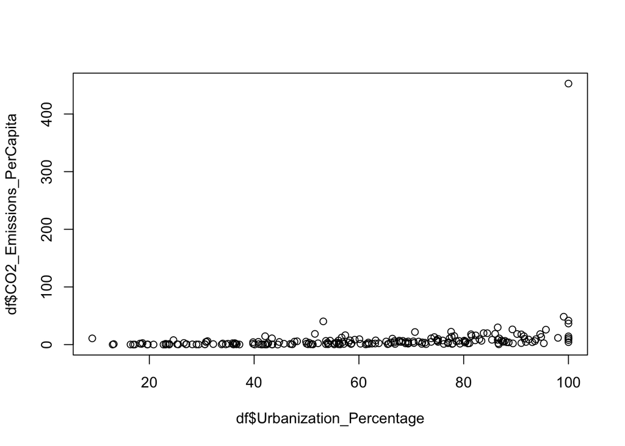

```r
plot(df$Urbanization_Percentage,df$CO2_Emissions_PerCapita)
```

Something seems to be going on with the data for Gibraltar. Gibraltar, is not technically its own country, so something seems to be going on with how the CIA is reporting some of this data. It would be more helpful to see this plot without Gibraltar. Let’s locate it, drop it, and save the resulting dataframe:

```r
df[76,]
```

```
##      Country CO2_Emissions_Number Urbanization_Percentage
## 76 Gibraltar             13340000                     100
##    GDP_Per_Capita_Number Population_Number CO2_Emissions_PerCapita
## 76                 61700             29461                 452.802
```

```r
df_noGib=df[-76, ]
```

Now, what does that look like if we plot again:

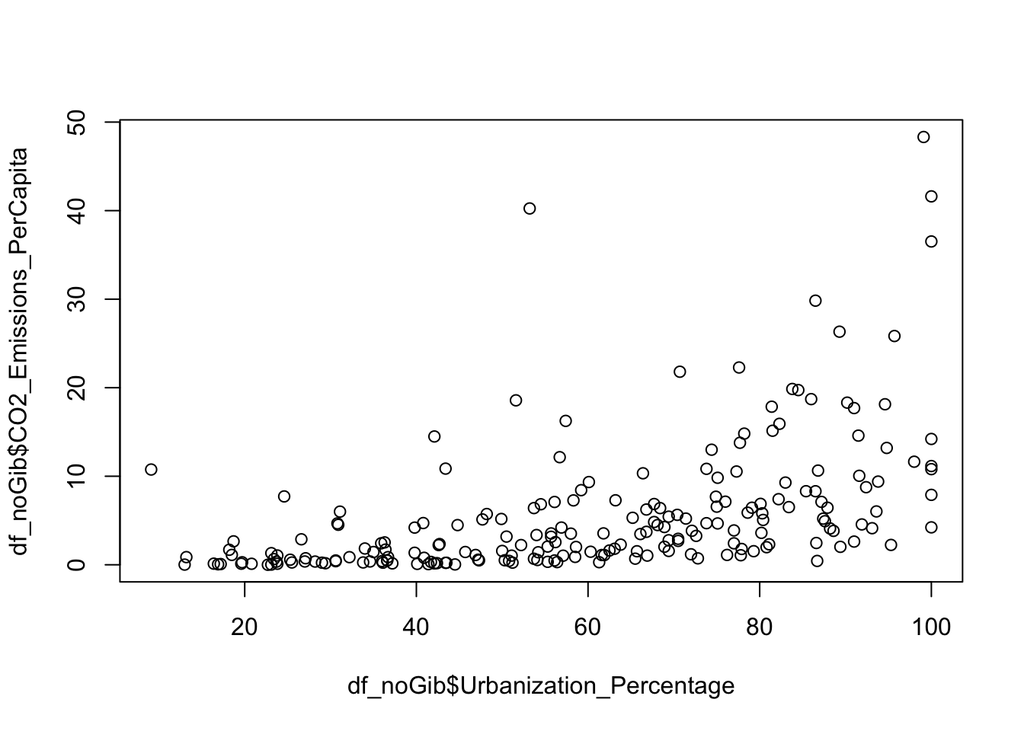

```r
plot(df_noGib$Urbanization_Percentage,df_noGib$CO2_Emissions_PerCapita)
```

We will plot GDP per capita as a function of CO2 emissions as well:

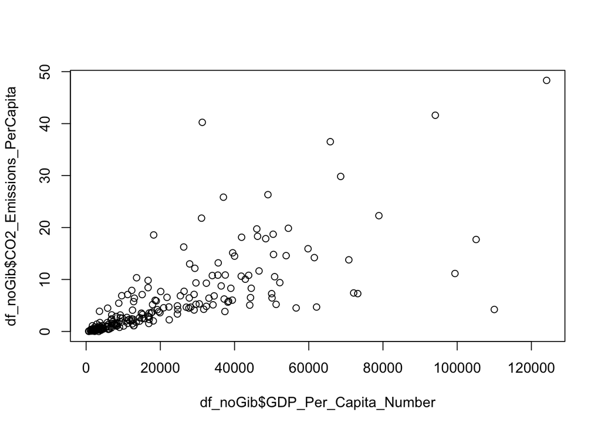

```r
plot(df_noGib$GDP_Per_Capita_Number,df_noGib$CO2_Emissions_PerCapita)
```

Visually, CO2 emissions per capita seem to be increasing as urbanization rates and GDP per capita increase.

## Looking at correlation strength between variables

It looks like there are higher CO2 emissions per capita as Urbanization rates and GDP per capita increase but let’s look at the correlation strengths. First for urbanization percentage and CO2 emissions per capita:

```r
cor(df_noGib$Urbanization_Percentage, df_noGib$CO2_Emissions_PerCapita)
```

```
## [1] 0.499226
```

And then for GDP per capita and CO2 emissions per capita:

```r
cor(df_noGib$GDP_Per_Capita_Number, df_noGib$CO2_Emissions_PerCapita)
```

```
## [1] 0.7346852
```

GDP_Per_Capita shows higher correlation with CO2 emissions than urbanization. This suggests that GDP per capita is more closely linked with CO2 emissions and vice versa than urbanization rates are with CO2 emissions.

## Creating a linear regression model

Knowing that we do have some correlation between our independent variables (urbanization rate & GDP per capita) and our dependent variable (CO2 emissions), we can try looking at a linear regression including all three variables to see how they interact.

First, let’s look at a linear regression of urbanization percentage and CO2 emissions and see how they interact:

```r
test1=lm(as.numeric(Urbanization_Percentage)~CO2_Emissions_PerCapita,data=df_noGib)
summary(test1)
```

```
##
## Call:
## lm(formula = as.numeric(Urbanization_Percentage) ~ CO2_Emissions_PerCapita,
##     data = df_noGib)
##
## Residuals:
##     Min      1Q  Median      3Q     Max
## -60.279 -15.308   1.557  15.147  42.360
##
## Coefficients:
##                         Estimate Std. Error t value Pr(>|t|)
## (Intercept)              51.0871     1.7702  28.859  < 2e-16 ***
## CO2_Emissions_PerCapita   1.5503     0.1861   8.329 1.07e-14 ***
## ---
## Signif. codes:  0 '***' 0.001 '**' 0.01 '*' 0.05 '.' 0.1 ' ' 1
##
## Residual standard error: 20.52 on 209 degrees of freedom
## Multiple R-squared:  0.2492, Adjusted R-squared:  0.2456
## F-statistic: 69.38 on 1 and 209 DF,  p-value: 1.066e-14
```

Emissions and urbanization show *significant correlation* however the adjusted R-squared value is only around 0.25, so the influence doesn’t seem to be very strong.

Now, we can look at a linear regression of GDP and CO2 emissions and see how they interact:

```r
test2=lm(as.numeric(GDP_Per_Capita_Number)~CO2_Emissions_PerCapita,data=df_noGib)
summary(test2)
```

```
##
## Call:
## lm(formula = as.numeric(GDP_Per_Capita_Number) ~ CO2_Emissions_PerCapita,
##     data = df_noGib)
##
## Residuals:
##    Min     1Q Median     3Q    Max
## -65419  -7665  -3981   3502  91420
##
## Coefficients:
##                         Estimate Std. Error t value Pr(>|t|)
## (Intercept)               9410.2     1317.9    7.14 1.52e-11 ***
## CO2_Emissions_PerCapita   2169.4      138.6   15.66  < 2e-16 ***
## ---
## Signif. codes:  0 '***' 0.001 '**' 0.01 '*' 0.05 '.' 0.1 ' ' 1
##
## Residual standard error: 15270 on 209 degrees of freedom
## Multiple R-squared:  0.5398, Adjusted R-squared:  0.5376
## F-statistic: 245.1 on 1 and 209 DF,  p-value: < 2.2e-16
```

GDP per capita shows *higher correlation* (adjusted R-squared of 0.54) with CO2 emissions than urbanization percentage did.

Lastly, let’s look at how both independent varibles affect CO2 emissions collectively with another linear regression:

```r
test3=lm(CO2_Emissions_PerCapita ~ GDP_Per_Capita_Number + Urbanization_Percentage, data=df_noGib)
summary(test3)
```

```
##
## Call:
## lm(formula = CO2_Emissions_PerCapita ~ GDP_Per_Capita_Number +
##     Urbanization_Percentage, data = df_noGib)
##
## Residuals:
##     Min      1Q  Median      3Q     Max
## -22.985  -1.660  -0.555   0.479  32.529
##
## Coefficients:
##                           Estimate Std. Error t value Pr(>|t|)
## (Intercept)             -1.036e+00  1.002e+00  -1.034    0.302
## GDP_Per_Capita_Number    2.305e-04  1.983e-05  11.625   <2e-16 ***
## Urbanization_Percentage  2.890e-02  1.886e-02   1.532    0.127
## ---
## Signif. codes:  0 '***' 0.001 '**' 0.01 '*' 0.05 '.' 0.1 ' ' 1
##
## Residual standard error: 5.156 on 208 degrees of freedom
## Multiple R-squared:  0.5449, Adjusted R-squared:  0.5405
## F-statistic: 124.5 on 2 and 208 DF,  p-value: < 2.2e-16
```

Again, while there is some correlation, the regression does not seem to be a perfect fit. Therefore, we will want to investigate the regression further to understand some potential reasons for this.

## Testing the regression

To test whether a linear regression is an appropriate tool to be using, we can look at whether our dependent variables seem normally distributed by looking a their fit on a QQ plot. We will call the “car” package and create the QQ plot:

```r
library(car)
```

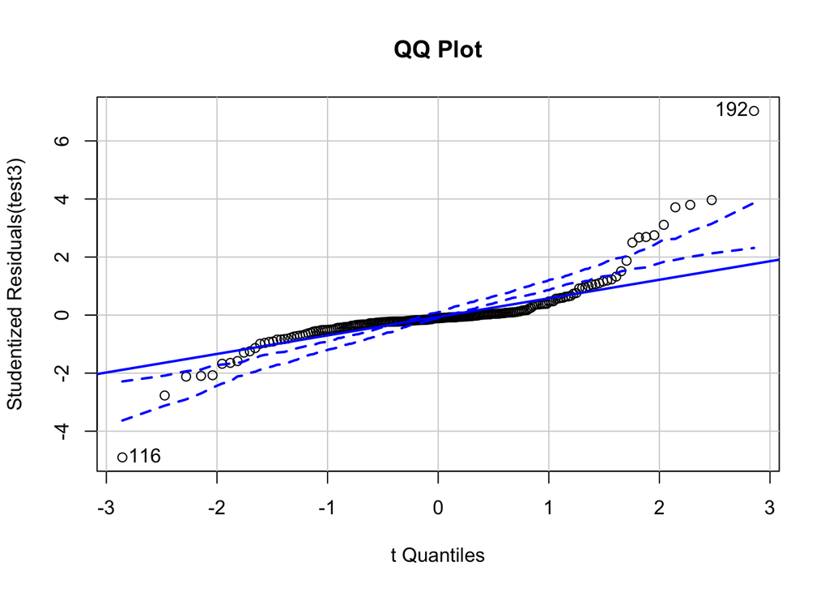

```
## 116 192
## 115 191
```

```r
qqPlot(test3, main="QQ Plot")
```

It looks like our variables fit a normal distribution more so in the middle quantiles. However, the fit is not as good at the more extreme values (“heavy tails”). This suggests that our data may have more extreme values than would be expected if all our data fell along a normal distribution. This is somewhat disconcerning for our ability to make inferences based on the assumption of having a normal distribution. But let’s see if we can investigate the amount of influence the extreme values are having on our data and maybe adjust for them.

```r
ncvTest(test3)
```

```
## Non-constant Variance Score Test
## Variance formula: ~ fitted.values
## Chisquare = 266.3711, Df = 1, p = < 2.22e-16
```

The p-value is less than a significance level of 0.05, so we can reject the null hypothesis that the variance of residuals is constant. Therefore, it seems that heteroscedasticity is present. *The error variance does change with the level of response.*

Next, let’s see if we can identify outliers that may be skewing our data:

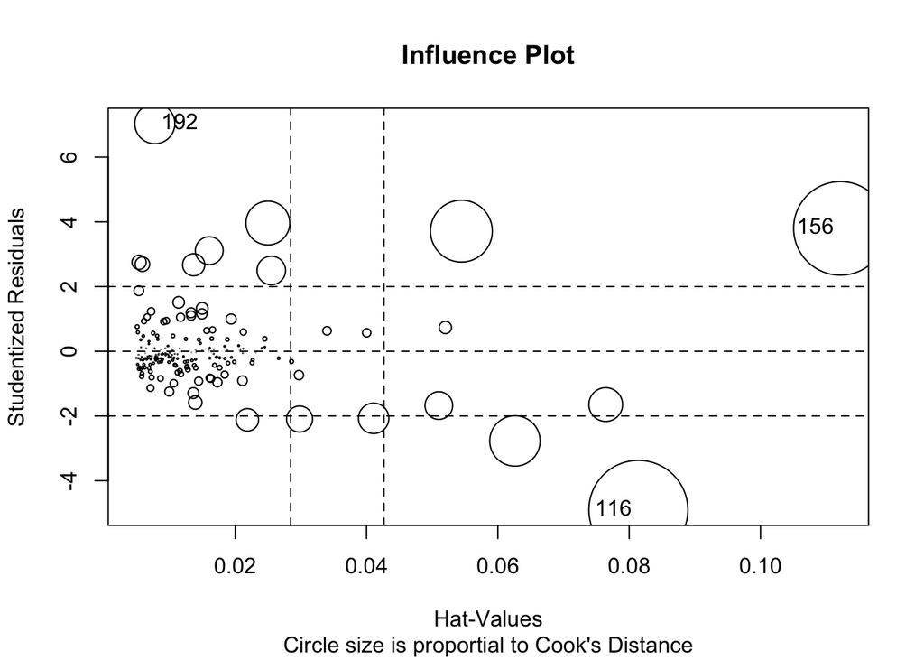

```
##       StudRes         Hat     CookD
## 116 -4.901570 0.081397699 0.6389066
## 156  3.797128 0.112162495 0.5703659
## 192  7.032364 0.007758282 0.1045402
```

```r
influencePlot(test3, id.method='noteworthy', main="Influence Plot", sub="Circle size is proportial to Cook's Distance" )
```

Rows 116, 156, and 192 seem to be disproportionate outliers. Let’s try dropping those rows from being considered and see if it makes a difference when we run the linear regression again:

```r
CountrysOUT=c(116,156,192)
summary(lm(CO2_Emissions_PerCapita ~ GDP_Per_Capita_Number + Urbanization_Percentage, data=df_noGib))
```

```
##
## Call:
## lm(formula = CO2_Emissions_PerCapita ~ GDP_Per_Capita_Number +
##     Urbanization_Percentage, data = df_noGib)
##
## Residuals:
##     Min      1Q  Median      3Q     Max
## -22.985  -1.660  -0.555   0.479  32.529
##
## Coefficients:
##                           Estimate Std. Error t value Pr(>|t|)
## (Intercept)             -1.036e+00  1.002e+00  -1.034    0.302
## GDP_Per_Capita_Number    2.305e-04  1.983e-05  11.625   <2e-16 ***
## Urbanization_Percentage  2.890e-02  1.886e-02   1.532    0.127
## ---
## Signif. codes:  0 '***' 0.001 '**' 0.01 '*' 0.05 '.' 0.1 ' ' 1
##
## Residual standard error: 5.156 on 208 degrees of freedom
## Multiple R-squared:  0.5449, Adjusted R-squared:  0.5405
## F-statistic: 124.5 on 2 and 208 DF,  p-value: < 2.2e-16
```